# Доклад по теме «Умение и удача»

Математическое моделирование

Ведьмина Александра Сергеевна

1132236003@rudn.ru

Российский университет дружбы народов

2026-04-24

## Содержание

- Информация
- Постановка задачи
- Математическая модель
- Параметры симуляции
- Результаты эксперимента
- Практические применения
- Выводы

# Информация

## Докладчик

- Ведьмина Александра Сергеевна
- студент
- Российский университет дружбы народов
- 1132236003@rudn.ru

# Постановка задачи

## Цель работы

Показать, как наблюдаемый результат раскладывается на устойчивую часть умения и случайную часть удачи, и почему при высокой доле шума отдельное наблюдение плохо отражает реальный уровень.

## Почему тема важна

- одна победа не доказывает превосходство;
- короткая доходность не доказывает качество стратегии;
- один тест не всегда точно отражает знания;
- одна метрика модели может оказаться случайной.

# Математическая модель

## Базовая формула

$$X = a \cdot Luck + (1-a) \cdot Skill, \qquad 0 < a < 1.$$

- `Skill` — стабильная составляющая;
- `Luck` — случайный шум;
- `a` — доля случайности в результате.

## Среднее и разброс

При `Luck ~ N(0,1)`:

$$\mathbb{E}[X] = (1-a)\cdot Skill,
\qquad
\mathrm{Var}(X) = a^2.$$

Для среднего по `n` попыткам:

$$\mathrm{Std}(\overline{X}_n) = \frac{a}{\sqrt{n}}.$$

- рост `a` делает отдельный исход менее надежным;
- рост `n` повышает точность оценки.

# Параметры симуляции

## Настройка эксперимента

| Параметр | Значение |
| --- | --- |
| `Skill` | `0.70` |
| `Luck` | `N(0,1)` |
| `a` | `0.2`, `0.5`, `0.8` |
| `n` | `200` |
| `Skill_A`, `Skill_B` | `0.82`, `0.58` |
| `a_compare` | `0.6` |

- построены отдельные серии результатов;
- вычислено накопленное среднее;
- исследованы распределения и надежность оценки;
- отдельно сравнены два участника.

# Результаты эксперимента

## Отдельные результаты

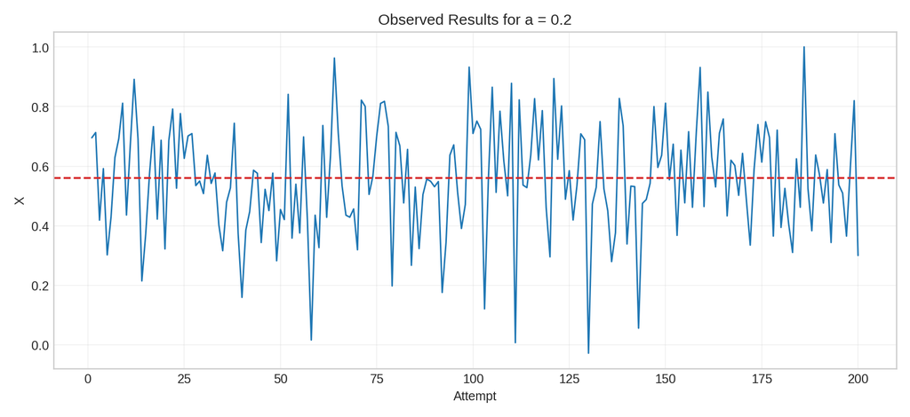

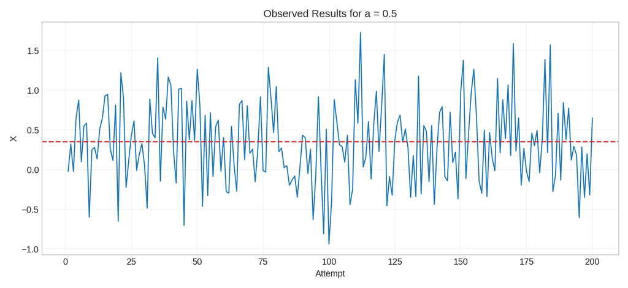

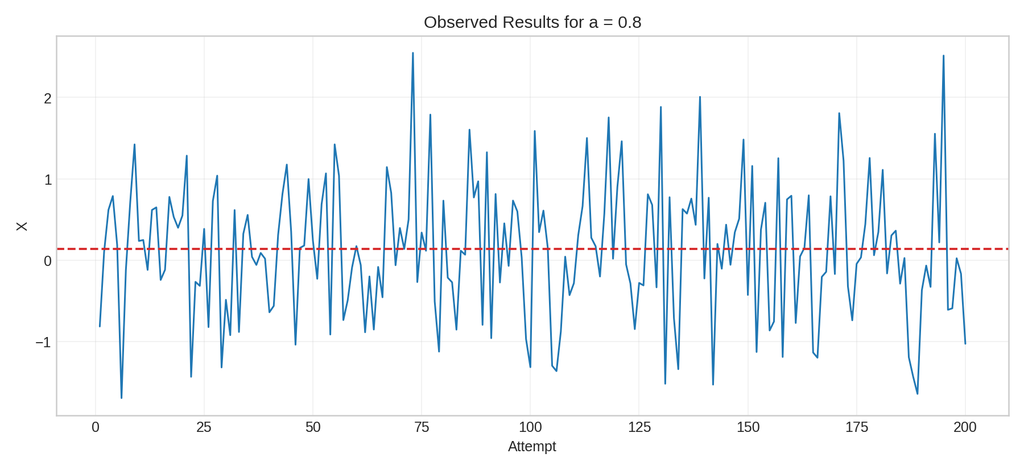

- при `a = 0.2` значения сгруппированы около среднего;
- при `a = 0.5` шум уже сопоставим с устойчивой частью;
- при `a = 0.8` единичный результат почти неинформативен.

## Накопленное среднее и распределения

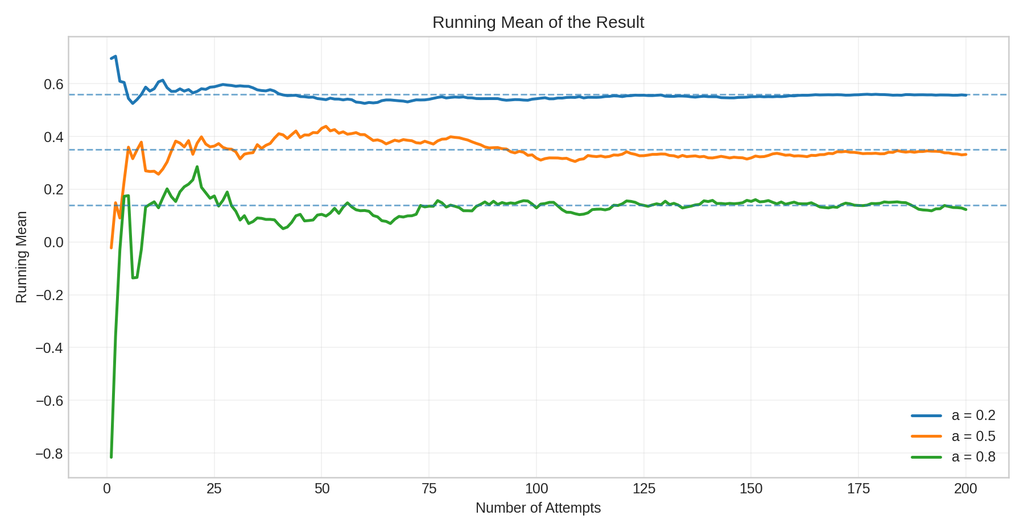

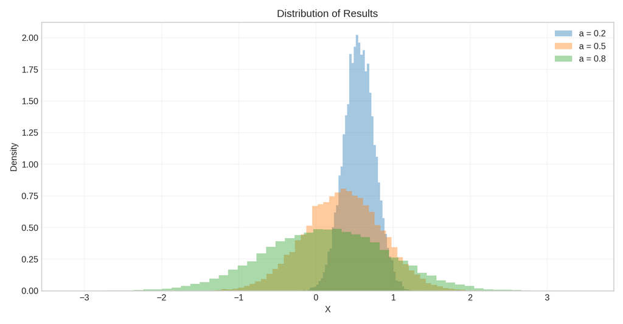

- среднее стабилизируется по мере роста числа попыток;
- высокая случайность замедляет стабилизацию;
- после `200` попыток получены значения `0.556`, `0.332`, `0.123`;
- при большом `a` распределение существенно шире.

## Надежность и сравнение участников

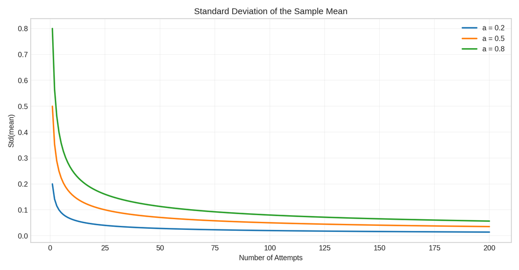

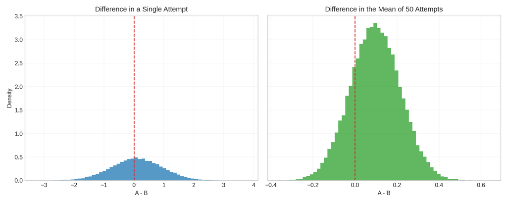

- стандартная ошибка среднего убывает как `a / sqrt(n)`;
- по одной попытке участник `A` лучше участника `B` лишь в `54.3%` случаев;
- по среднему из `50` попыток это уже `79.0%`;
- разброс разности падает с `0.849` до `0.120`.

## Теоретическая сводка

| `a` | `E[X]` | `Var(X)` |
| --- | --- | --- |
| `0.2` | `0.56` | `0.04` |
| `0.5` | `0.35` | `0.25` |
| `0.8` | `0.14` | `0.64` |

- вклад удачи растет нелинейно;
- для интерпретации результатов важна длина серии, а не единичный исход.

# Практические применения

## Где модель полезна

- спорт: сезон информативнее одного матча;
- финансы: длинная история важнее отдельного удачного периода;
- образование: серия независимых заданий лучше одного теста;
- машинное обучение: несколько запусков надежнее одной метрики.

# Выводы

## Итоги

- результат естественно рассматривать как смесь умения и удачи;
- при высоком `a` единичное наблюдение ненадежно;
- среднее по длинной серии приближает устойчивую часть результата;
- исходный материал оформлен как стандартный отчет и презентация с воспроизводимой симуляцией и графиками.